# Does Money Buy Health? A Global Look at GDP and Life Expectancy

Author

Jafar

Published

April 26, 2025

# Introduction

We use economic progress as the main indicator of national success within our globalized framework of today. Will rising economic numbers bring permanent advantages to citizens’ overall welfare? The research delves into whether greater personal income actually results in extended life expectancy and improved health among people.

A comparison of GDP per capita and life expectancy data from UNICEF alongside global indicators analyzes these indicators across different countries. The data analysis corresponds to two primary United Nations Sustainable Development Goals (SDGs) which are:

SDG 3: Good Health and Well-being

SDG 8: Decent Work and Economic Growth.

The report demonstrates that economic wealth supports public health initiatives although other variables contribute to health outcomes. Healthcare funding together with educational investments and establishing social equality guarantees people live longer and healthier lives without regard to their birthplace.

# GDP vs Life Expectancy (Scatter Plot)

[figure not shown]

```python
from plotnine import *

(
  ggplot(df_clean.to_pandas().query("year == 2015")) +
  aes(
      x='GDP per capita (constant 2015 US$)', # Changed to single quotes
      y='Life expectancy at birth, total (years)', # Changed to single quotes
      color='country' # Changed to single quotes
  ) +
  geom_point(alpha=0.6, size=3) +
  geom_smooth(method='lm', se=False, color="black") +
  theme_minimal() +
  labs(
      title="GDP per Capita vs Life Expectancy (2015)",
      x="GDP per Capita (US$)",
      y="Life Expectancy (Years)"
  )
)
```

# Life Expectancy Trends (Time-Series)

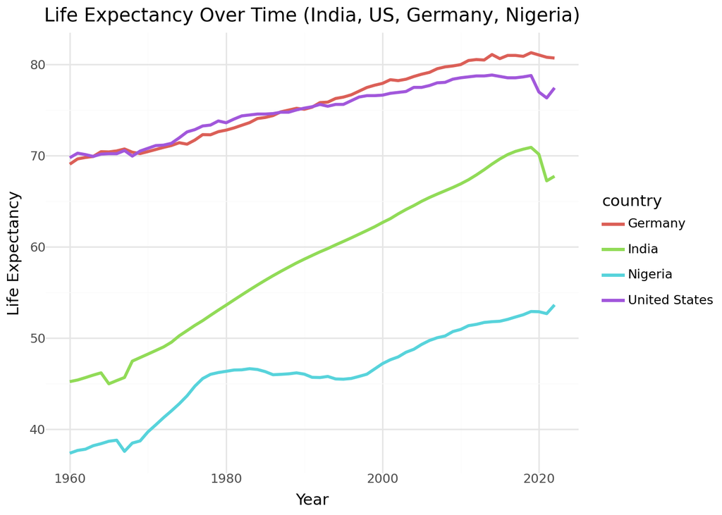

```python
countries = ["India", "United States", "Germany", "Nigeria"]
df_subset = df_clean.filter(pl.col("country").is_in(countries))
df_subset = df_subset.rename({"Life expectancy at birth, total (years)": "life_expectancy"})

(
  ggplot(df_subset.to_pandas()) +
  aes(x="year", y="life_expectancy", color="country") +
  geom_line(size=1.2) +
  theme_minimal() +
  labs(
      title="Life Expectancy Over Time (India, US, Germany, Nigeria)",
      x="Year",
      y="Life Expectancy"
  )
)
```

# Top 10 Countries by Life Expectancy

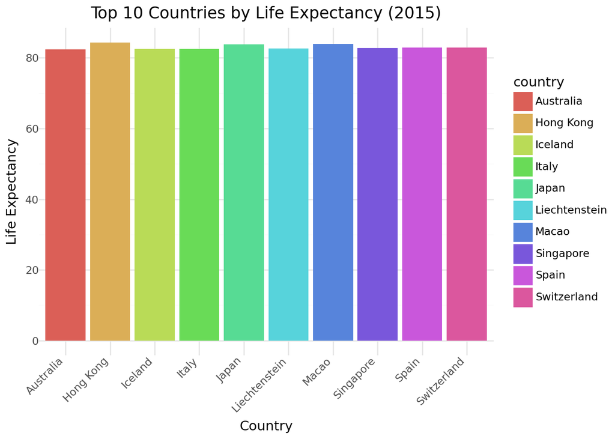

```python
top10 = (
    df_clean.filter(pl.col("year") == 2015)
    .sort("Life expectancy at birth, total (years)", descending=True)
    .head(10)
)

(
  ggplot(top10.to_pandas()) +
  aes(x="country", y="Life expectancy at birth, total (years)", fill="country") + # Removed backticks from column name
  geom_col() +
  theme_minimal() +
  labs(
      title="Top 10 Countries by Life Expectancy (2015)",
      x="Country",
      y="Life Expectancy"
  ) +
  theme(axis_text_x=element_text(rotation=45, ha="right"))
)
```

# Global Life Expectancy Map

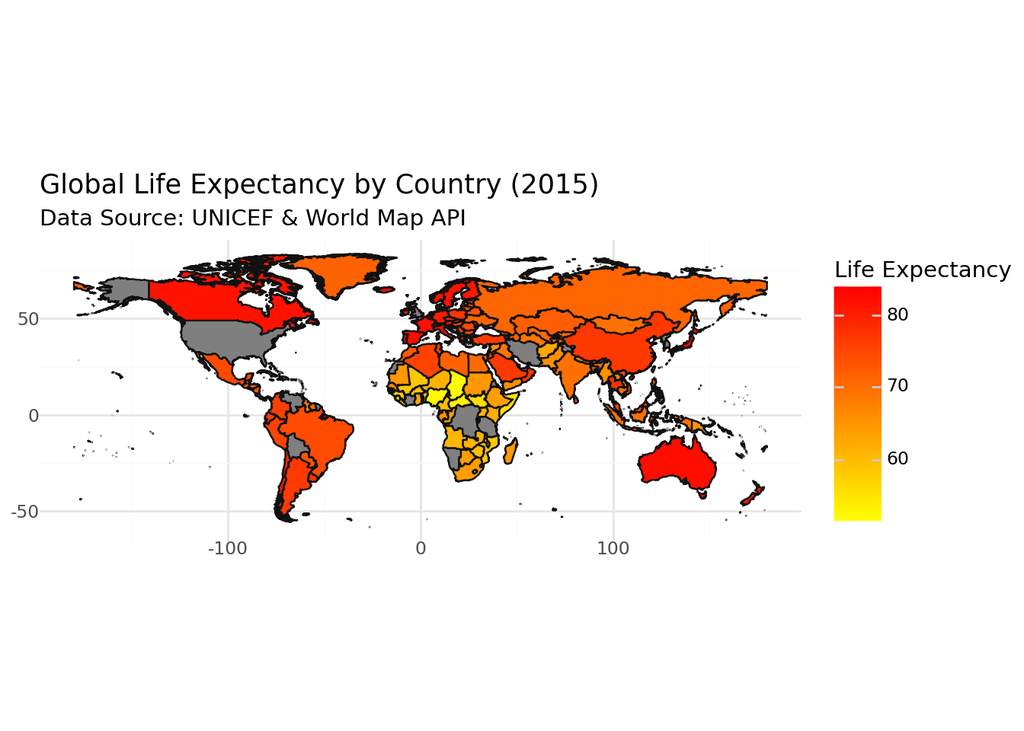

```python
# Load shape file
shape_world = gpd.read_file("https://public.opendatasoft.com/api/explore/v2.1/catalog/datasets/world-administrative-boundaries/exports/shp")

# Join with data
lifeexp_2015 = (
    df_clean.filter(pl.col("year") == 2015)
    .to_pandas()
)
map_data = shape_world.merge(lifeexp_2015, how="left", left_on="name", right_on="country")

# Plot map
from plotnine import *

(
  ggplot(map_data) +
  aes(fill="Life expectancy at birth, total (years)") + # Removed backticks around column name
  geom_map() +
  coord_fixed() +
  scale_fill_gradient(low="yellow", high="red") +
  labs(
      title="Global Life Expectancy by Country (2015)",
      subtitle="Data Source: UNICEF & World Map API",
      fill="Life Expectancy"
  ) +
  theme_minimal()
)
```

# Conclusion

The report presents data which shows dramatic life expectancy variations between nations together with their financial capability. Numerous elements apart from GDP determine life expectancy levels but GDP serves as a crucial determinant.

**UNICEF and its partners must continue pushing for equity in health outcomes across all nations.**